# Social classes in cities in the state of Kentucky

Noah Kiefer

2025-04-29

# Introduction

This individual homework in the module SBD3 (Advanced Analytics for Decision-Making) in the spring semester 2025 at Bern University of Applied Sciences deals with the topic of unsupervised learning.

Public data from the American Community Survey (ACS) is analyzed using clusters. The aim is to analyze different city clusters and interpret their characteristics. The data comes from all available cities in the state of **Kentucky**. You ask me why? I just picked it at random. The state of Kentucky is located in the east of the USA.

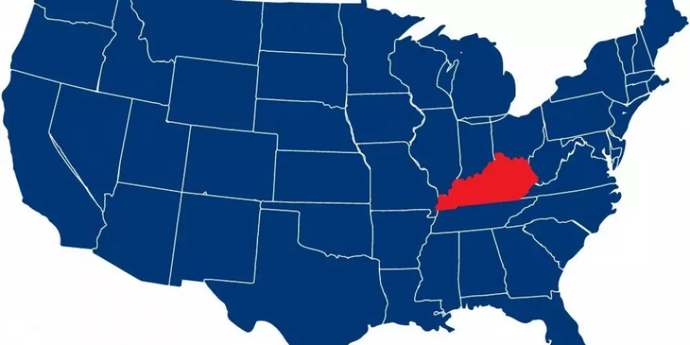

My question for this individual homework is whether the cities in the state of Kentucky can be divided into two or more socio-economic clusters. For this purpose, I have chosen the two main variables Employment Percentage and Median Household Income in Dollars.

In my analysis, I include additional variables:

- Work from Home Percentage
- Family Household Percentage
- Housing Vacancy Percentage

I find these three variables interesting to analyze and I think I can draw a good conclusion from them as to whether it is a poorer or a richer city.

# Data Preparation

## Load Dataset

That I can carry out the analyses, I have selected three datasets on the topics of **income**, **employment** and **housing**. These will be loaded into the environment first.

```r
# Import Dataset from Working Directory (set WD manually!)
data_income <- read.csv("income.csv", header = TRUE)
data_employment <- read.csv("employment.csv", header = TRUE)
data_housing <- read.csv("housing.csv", header = TRUE)
```

## Prepare Dataset

After importing the data, the data must be prepared so that it is useful for the analysis. This involves standardizing the data and deleting rows with empty cells.

## Outliers

The next step is to take a look at the outliers and remove them if necessary. I do this for the five variables that I will use later for my analysis. The five variables can be seen below in boxplots. Outliers are recognized in all five, which I have removed.

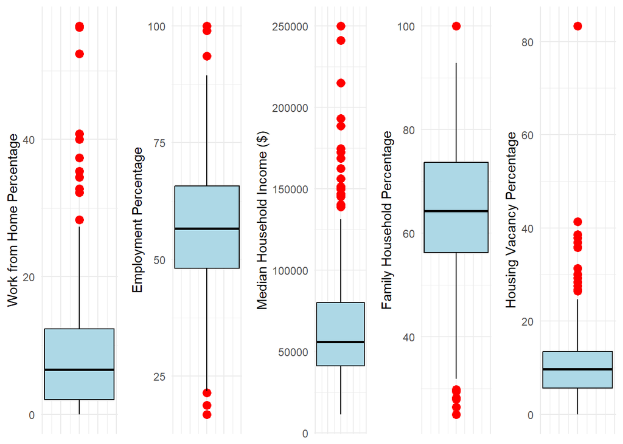

# Data exploration

## Analyse Summary

In the data exploration, I recognize **12 variables and 434 observations**. All twelfe variables are numerical. For each variable, you get information such as the mean and median as well as other statistical facts.

```
## 'data.frame':    434 obs. of  12 variables:
##  $ Population_16_and_over                : num  608 233 1660 8181 106 ...
##  $ Population_16_and_over_in_labour_force: num  342 140 866 5711 76 ...
##  $ Work_from_Home_Percentage             : num  8.7 0 4 13.8 15.6 0 0 0 8.5 0 ...
##  $ Employment_Percentage                 : num  56.2 60.1 52.2 69.8 71.7 ...
##  $ Households_Total                      : num  349 118 847 3755 74 ...
##  $ Median_Household_Income_in_dollars    : num  43661 45333 40301 103750 33036 ...
##  $ Families_Total                        : num  199 70 486 2849 34 ...
##  $ Familiy_Household_Percentage          : num  57 59.3 57.4 75.9 45.9 ...
##  $ Total_Housing                         : num  401 149 973 3969 89 ...
##  $ Total_Housing_Occupied                : num  357 135 809 3819 83 ...
##  $ Total_Housing_Vacant                  : num  44 14 164 150 6 10 43 15 22 29 ...
##  $ Housing_Vacancy_Percentage            : num  10.97 9.4 16.86 3.78 6.74 ...
##  - attr(*, "na.action")= 'omit' Named int [1:65] 7 18 27 30 34 40 41 45 58 61 ...
##   ..- attr(*, "names")= chr [1:65] "7" "19" "28" "31" ...
```

```
##  Population_16_and_over Population_16_and_over_in_labour_force
##  Min.   :    64         Min.   :    18.0
##  1st Qu.:   400         1st Qu.:   212.0
##  Median :   924         Median :   503.5
##  Mean   :  4828         Mean   :  3032.3
##  3rd Qu.:  2726         3rd Qu.:  1475.5
##  Max.   :501155         Max.   :329160.0
##  Work_from_Home_Percentage Employment_Percentage Households_Total
##  Min.   : 0.000            Min.   :21.87         Min.   :    25.0
##  1st Qu.: 2.125            1st Qu.:48.05         1st Qu.:   210.8
##  Median : 6.150            Median :56.23         Median :   455.0
##  Mean   : 7.405            Mean   :55.87         Mean   :  2472.8
##  3rd Qu.:11.100            3rd Qu.:64.69         3rd Qu.:  1307.8
##  Max.   :27.300            Max.   :84.15         Max.   :262740.0
##  Median_Household_Income_in_dollars Families_Total
##  Min.   : 11563                     Min.   :    13.0
##  1st Qu.: 40313                     1st Qu.:   127.5
##  Median : 52666                     Median :   288.5
##  Mean   : 59132                     Mean   :  1460.2
##  3rd Qu.: 74030                     3rd Qu.:   827.0
##  Max.   :131250                     Max.   :152215.0
##  Familiy_Household_Percentage Total_Housing      Total_Housing_Occupied
##  Min.   :31.85                Min.   :    37.0   Min.   :    29.0
##  1st Qu.:55.88                1st Qu.:   224.0   1st Qu.:   198.8
##  Median :62.71                Median :   488.5   Median :   429.0
##  Mean   :63.40                Mean   :  2400.2   Mean   :  2202.0
##  3rd Qu.:71.30                3rd Qu.:  1487.5   3rd Qu.:  1363.5
##  Max.   :92.88                Max.   :164238.0   Max.   :154713.0
##  Total_Housing_Vacant Housing_Vacancy_Percentage
##  Min.   :    0.00     Min.   : 0.000
##  1st Qu.:   21.25     1st Qu.: 6.410
##  Median :   53.00     Median : 9.829
##  Mean   :  198.16     Mean   :10.059
##  3rd Qu.:  147.00     3rd Qu.:13.299
##  Max.   :11607.00     Max.   :24.632
```

## Scale Data

Another step I perform is scaling the data. I do this because many clustering algorithms are distance-based, i.e. they calculate the distance between data points to determine their similarity or dissimilarity. If we do not scale the data, data with larger scales or variances will dominate the distance calculations, and variables with smaller scales or variances will have less influence on the clustering results. This can lead to biased or inaccurate clustering results.

If we look at the summary of the scaled data, we can see that the mean is 0 for every variable. This means that the data has been standardized correctly.

```
##  Population_16_and_over Population_16_and_over_in_labour_force
##  Min.   :-0.17277       Min.   :-0.16534
##  1st Qu.:-0.16058       1st Qu.:-0.15470
##  Median :-0.14158       Median :-0.13871
##  Mean   : 0.00000       Mean   : 0.00000
##  3rd Qu.:-0.07623       3rd Qu.:-0.08539
##  Max.   :17.99894       Max.   :17.88872
##  Work_from_Home_Percentage Employment_Percentage Households_Total
##  Min.   :-1.1532           Min.   :-2.74725      Min.   :-0.16917
##  1st Qu.:-0.8223           1st Qu.:-0.63143      1st Qu.:-0.15633
##  Median :-0.1954           Median : 0.02936      Median :-0.13945
##  Mean   : 0.0000           Mean   : 0.00000      Mean   : 0.00000
##  3rd Qu.: 0.5755           3rd Qu.: 0.71276      3rd Qu.:-0.08052
##  Max.   : 3.0986           Max.   : 2.28526      Max.   :17.98711
##  Median_Household_Income_in_dollars Families_Total
##  Min.   :-1.8919                    Min.   :-0.17472
##  1st Qu.:-0.7485                    1st Qu.:-0.16090
##  Median :-0.2572                    Median :-0.14146
##  Mean   : 0.0000                    Mean   : 0.00000
##  3rd Qu.: 0.5925                    3rd Qu.:-0.07644
##  Max.   : 2.8682                    Max.   :18.20138
##  Familiy_Household_Percentage Total_Housing      Total_Housing_Occupied
##  Min.   :-2.72254             Min.   :-0.21575   Min.   :-0.21310
##  1st Qu.:-0.64862             1st Qu.:-0.19868   1st Qu.:-0.19645
##  Median :-0.05925             Median :-0.17453   Median :-0.17387
##  Mean   : 0.00000             Mean   : 0.00000   Mean   : 0.00000
##  3rd Qu.: 0.68193             3rd Qu.:-0.08332   3rd Qu.:-0.08223
##  Max.   : 2.54406             Max.   :14.77532   Max.   :14.95601
##  Total_Housing_Vacant Housing_Vacancy_Percentage
##  Min.   :-0.2553      Min.   :-1.9954
##  1st Qu.:-0.2279      1st Qu.:-0.7238
##  Median :-0.1870      Median :-0.0456
##  Mean   : 0.0000      Mean   : 0.0000
##  3rd Qu.:-0.0659      3rd Qu.: 0.6426
##  Max.   :14.6962      Max.   : 2.8908
```

# Data Analysis

## Cluster Employment Percentage & Median Household Income in Dollars (Part 1)

### Define Cluster Size

In my first cluster analysis, I decided to analyze the two variables (Employment Percentage and Median Household Income in Dollars). This is because I want to see if cities with higher employment percentages also have higher median incomes.

First I show the data on a plot. Both plots show the median household income in dollars on the y-axis and the employment percentage on the x-axis.

The left plot is with the real data, and the right plot is with the scaled data. apart from the different numbers on the two axes, I don’t see any difference

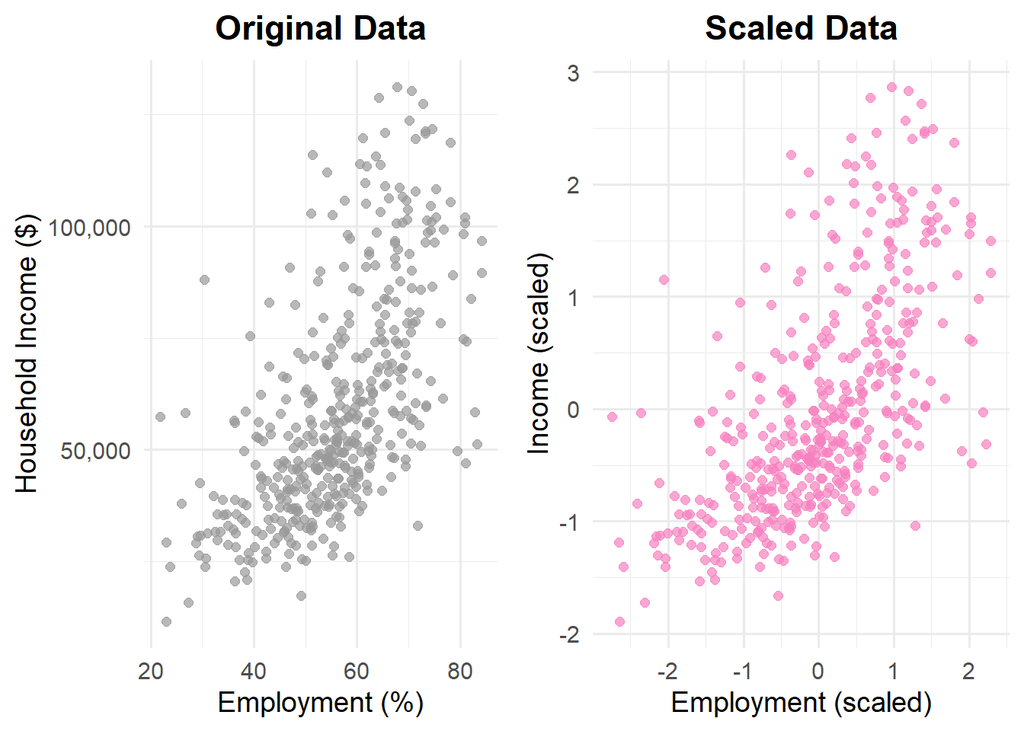

In the next step I use the Elbow method to find out what the optimal cluster size is. I find this out by looking at the plot and reading at which number on the x axis the line flattens, similar to the elbow on the human body. In our case, this is the number 2, although you can also discuss the number 3, but I think the number 2 is more meaningful because you can see a clearer flattening. This means that we are initially considering **two clusters** for our analysis.

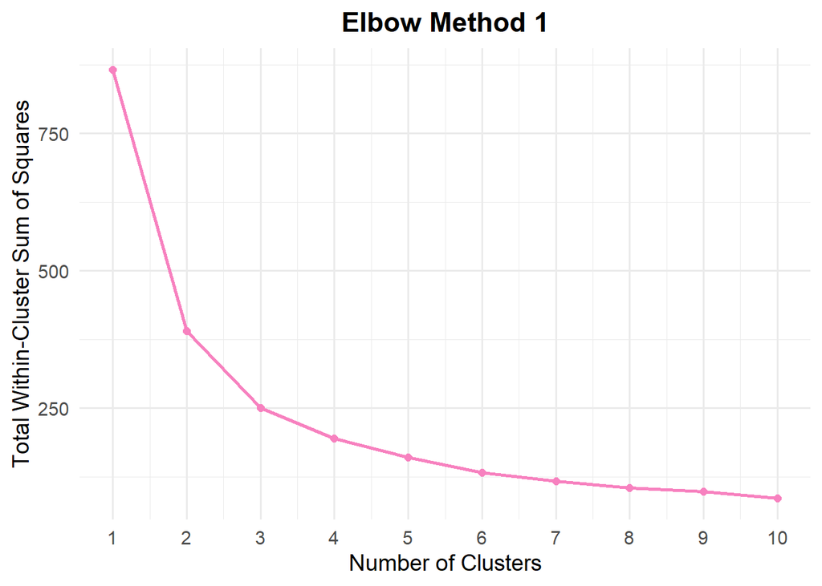

### K-Means Algorithm

As determined in the previous analysis, the optimal number of clusters is two.

The K-Means analysis carried out divides the data into two clusters accordingly: **The larger cluster comprises 270 observations, the smaller 164**.

- Cluster 1 (164 observations) shows above-average values in both dimensions and thus represents a more affluent and more employed cluster.
- Cluster 2 (270 Observations), on the other hand, shows below-average values for both median household income and employment rate. It is therefore a comparatively socially weaker and less employed segment.

```r
kmeans_model[["size"]]
```

```
## [1] 164 270
```

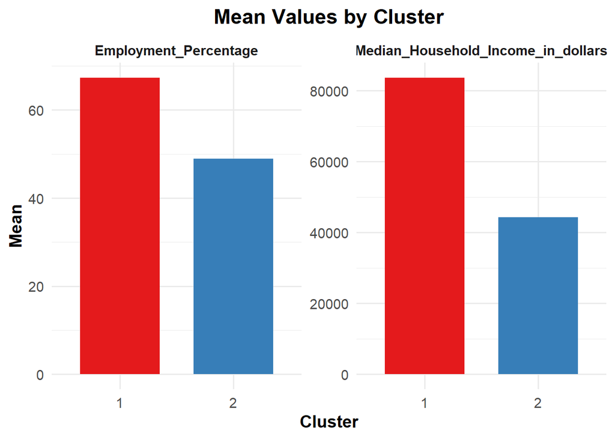

If we now apply these two clusters to our plot from above, this can be seen as follows.

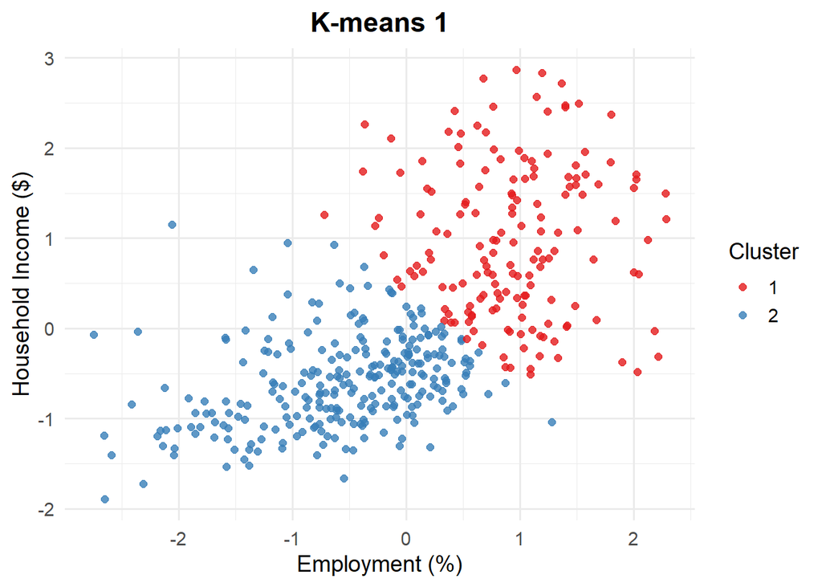

### Analysis using PCA and K-Means Clustering

To better visualize the clustering results, a principal component analysis (PCA) was performed on the two variables. PCA reduces the original variables to two principal components (PC1 and PC2).

The two principal components together explain 100 % of the total variance in the data **(PC1 = 81.2 %, PC2 = 18.8 %)**, which is to be expected since only two variables were analyzed. This means that no information is lost and the two-dimensional representation of the data allows a complete mapping.

The contributions of the variables to the two main components are evenly distributed: both variables contribute 50 % to the first and 50 % to the second component. Thus, no dominant influence of a single variable on one of the components can be determined.

```r
# Evaluation of PCA
pca_fit$eig
```

```
##        eigenvalue percentage of variance cumulative percentage of variance
## comp 1  1.6234016               81.17008                          81.17008
## comp 2  0.3765984               18.82992                         100.00000
```

```r
pca_fit$var$contrib
```

```
##                                    Dim.1 Dim.2
## Employment_Percentage                 50    50
## Median_Household_Income_in_dollars    50    50
```

The left-hand diagram shows the clusters based on the original data of the two variables, while the right-hand diagram shows the same clusters after a PCA transformation. In PCA, the data is rotated to new axes (PC1 and PC2), which show the greatest variance. This changes the appearance of the distribution, although the group membership remains the same. The difference is that the real variables are shown on the left and a mathematically optimized view on the right for better separation.

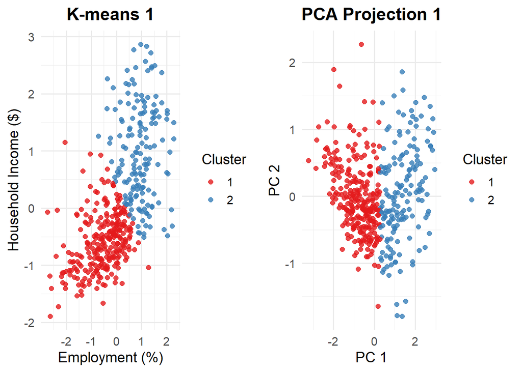

### Hierarchical Clustering (Single & Complete Linkage)

For further investigation, I carried out hierarchical clustering on the standardized variables. First, a distance matrix was calculated to capture the similarities between the observations.

Subsequently, two methods of hierarchical clustering were applied:

- Single Linkage (Minimum Distance): Links the two closest observations or clusters in each case.
- Complete linkage (maximum distance): Links clusters based on the maximum distance between their observations.

A cluster number of k = 2 was selected for both methods. The resulting dendrograms show the hierarchical structure of the data. By color-coding the branches (with rect.hclust), the two clusters are visually highlighted.

I found out that in our case, single linkage doesn’t really make sense, as this is rather bad for clearly defined groups. However, complete linkage can recognize compact and clearly separated clusters better. We can also see this in the two diagrams shown.

Although there are two clusters in Single Linkage, one cluster only has one point. The complete Linkage performs significantly better.

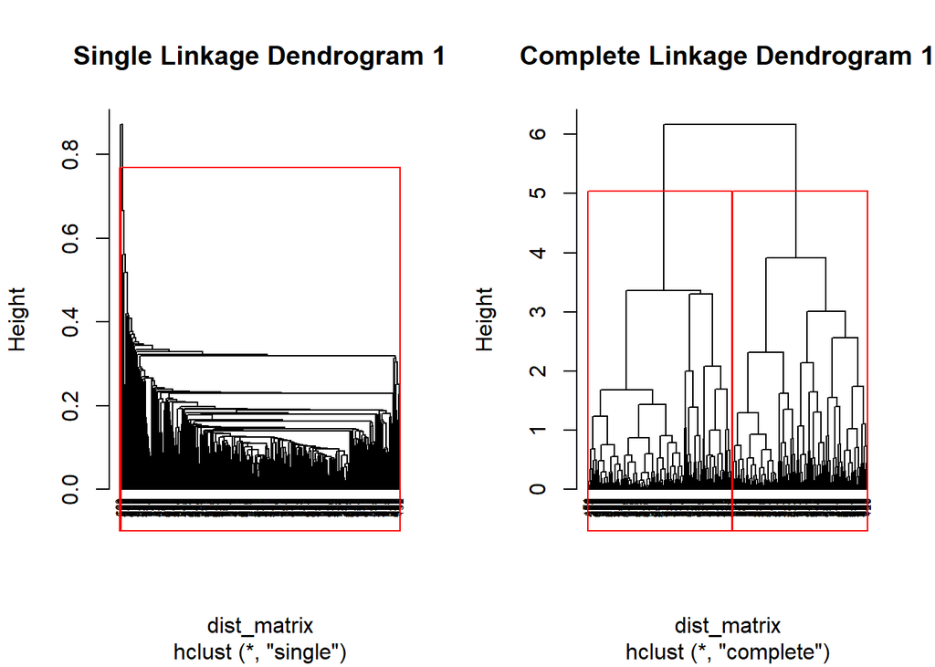

I have also applied the two hierarchical clustering methods to our plot with the data, and this looks like this. Again, you can see what I described above. With single linkage, there are two clusters, but they are useless. On the other hand, Complete Linkage is much better and quite similar to the K-means cluster.

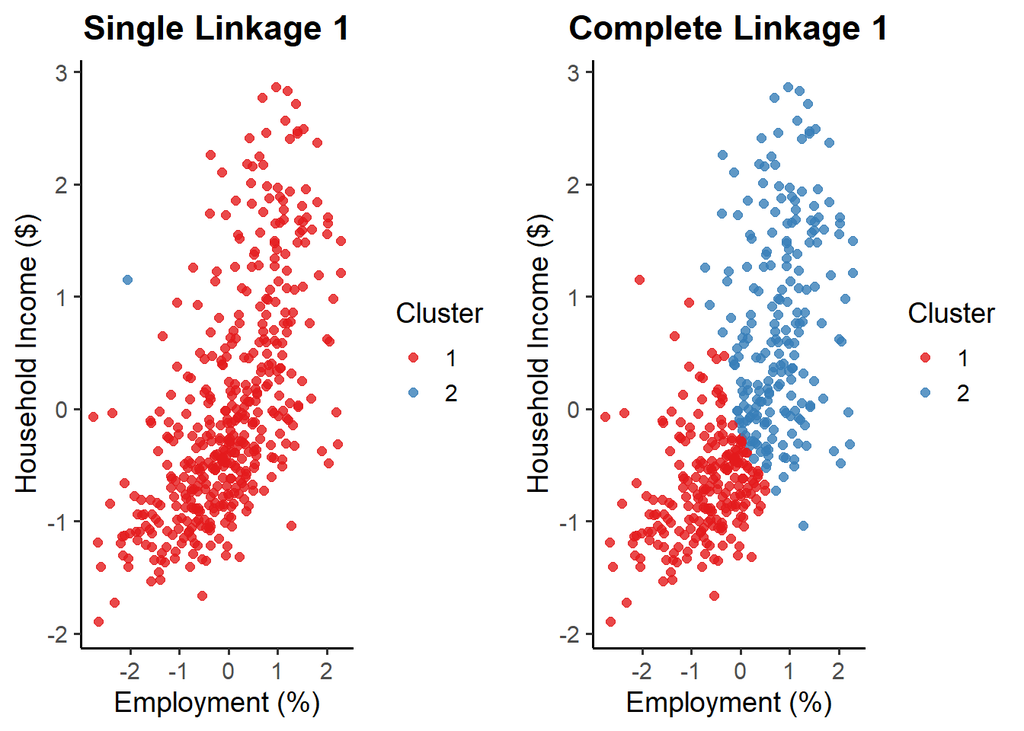

### DB-Scan Clustering

Next, I use DB scan clustering. This is a density-based clustering method where no number of clusters are defined in advance. With the parameters, regions with higher density can be identified, while observations outside are classified as noise.

The resulting clusters were visualized both with the original variables (employment rate and median income) and in PCA space. In both cases, clear cluster structures can be recognized.

I decided to set “MinPts” to 3 and “eps” to 0.5, as this made the most sense from my point of view. As already mentioned, a large cluster was recognized (blue).

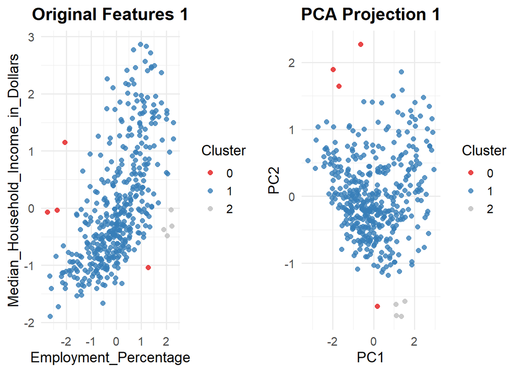

### Silhouette width

The silhouette width indicates the quality of the cluster analysis. It shows how well a point matches its own cluster compared to other clusters. The value ranges from -1 to +1.

- Close to +1 means points are well grouped and clearly separated from other clusters
- Close to 0 means that the point is on the border or between two clusters
- Close to -1 means that the point is in a wrong cluster

In our case, all five species are rather average. However, the best are k-means and pca with k-means of **0.47** each. In our case, however, the PCA has no influence on the result of the silhouette width. I think this could be due to the fact that I only worked with two variables in this part.

```
## Average Silhouette Width for K-Means Clustering: 0.4728028
```

```
## Average Silhouette Width for Single Linkage Clustering: 0.3405756
```

```
## Average Silhouette Width for Complete Linkage Clustering: 0.4381768
```

```
## Average Silhouette Width for DBSCAN Clustering: 0.145124
```

```
## Average Silhouette Width for PCA and K-Means Clustering: 0.4728028
```

## Add three extra Variables (Part 2)

### Define Cluster Size

In my second cluster analysis, I decided to add three more variables (Work from Home Percentage, Family Household Percentage and Housing Vacancy Percentage). I want to find out whether these three variables have an effect on the number of clusters and the cluster sizes.

Again, I use the Elbow method to find out what the optimal cluster size is. The diagram shows me that we can again divide the data optimally into **two clusters**.

To illustrate this, I have shown both plots in this part of the analysis, each in its own color palette. With the Elbow method, it can be seen that in the second analysis, with five variables, the line does not fall off as quickly, but as already described, two clusters are still the best.

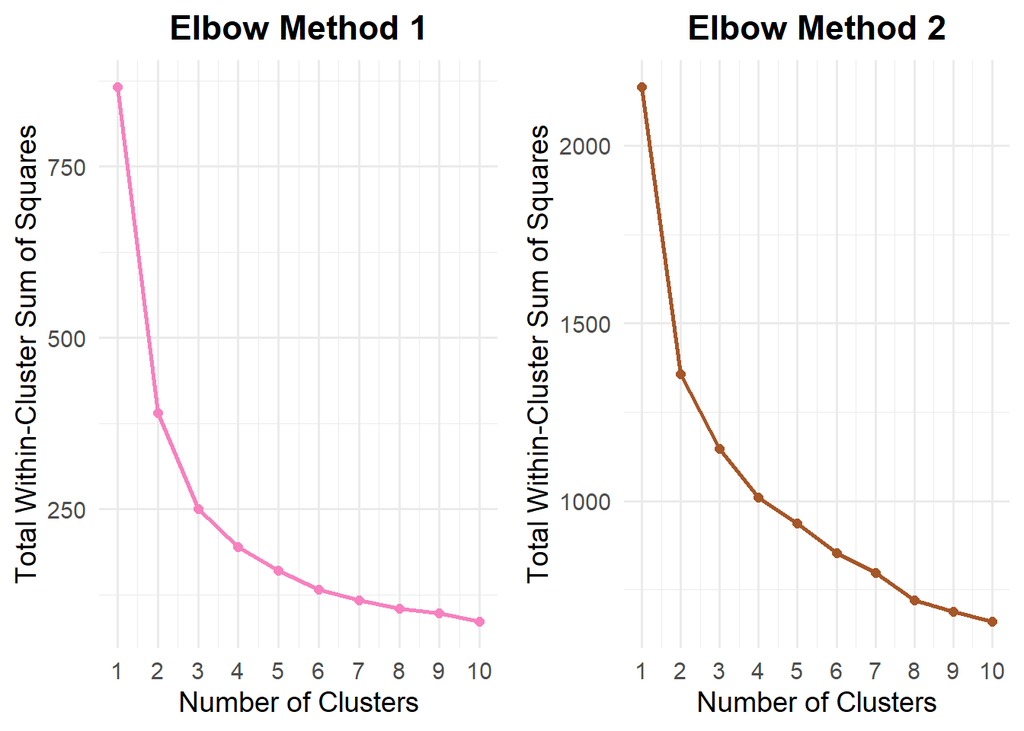

### K-Means Algorithm

As determined in the previous analysis, the optimal number of clusters is two.

In the K-Means analysis performed, the data is divided into two clusters accordingly: **The larger cluster comprises 284 observations, the smaller 150**. This is a difference of -14/+14 to the cluster in the previous chapter.This is a small change in the cluster sizes, but if this is extrapolated to the total of 434 observations, 14 observations account for around 3.2%.

```r
kmeans_model_2[["size"]]
```

```
## [1] 150 284
```

However, it is particularly interesting to look at the mean values of the variables. Cluster 1, the “wealthier” cluster, has higher values for Employment Percentage, Family Household Percentage, Median Household Income in Dollars and Work from Home Percentage. In contrast, Cluster 2, the “poorer” cluster, only shows a higher value for Housing Vacancy Percentage.

What I find most interesting is the Work from Home Percentage. This indicates that people in wealthier cities are more likely to work from home - an interesting trend that points to the higher proportion of occupations that can be performed remotely.

The second interesting point is the Family Household Percentage. Here I was initially surprised as I had expected the ‘poorer’ cluster to have a higher percentage of family households. However, the data showed the opposite and proved me wrong.

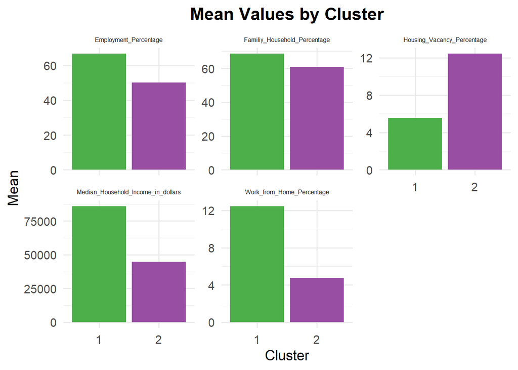

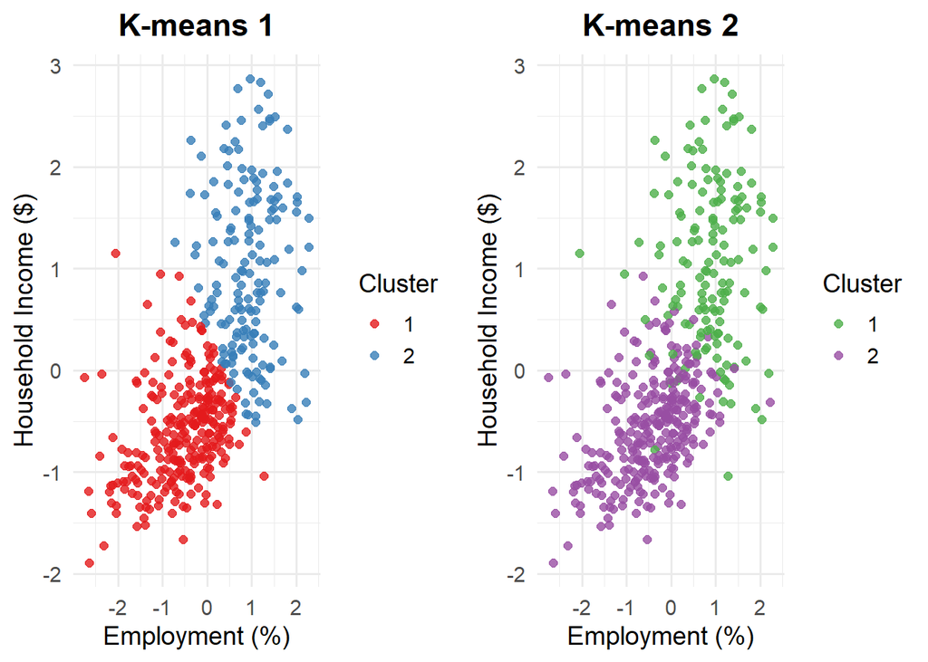

### Analysis using PCA and K-Means Clustering

I also perform a PCA analysis with the additional variables.

The two main components together explain 73.5 % of the total variance in the data **(PC1 = 53.1 %, PC2 = 20.5 %)**. The value of 73.5% is a high value and indicates that the first two principal components cover a large proportion of the information from the original variables.

Comp 1 (first principal component) explains most of the variance (53.05%) and correlates strongly with the variables Median Household Income and Employment Percentage.

Comp 2 (second principal component) explains 20.48% of the variance and correlates strongly with the Work from Home Percentage and Family Household Percentage variables.

```r
# Evaluation of PCA
pca_fit_2$eig
```

```
##        eigenvalue percentage of variance cumulative percentage of variance
## comp 1  2.6525026              53.050051                          53.05005
## comp 2  1.0241858              20.483717                          73.53377
## comp 3  0.5637484              11.274968                          84.80874
## comp 4  0.4979910               9.959820                          94.76856
## comp 5  0.2615722               5.231444                         100.00000
```

```r
pca_fit_2$var$contrib
```

```
##                                        Dim.1      Dim.2     Dim.3       Dim.4
## Work_from_Home_Percentage          17.332013 23.9504270 46.569187  0.27967780
## Employment_Percentage              23.291591  0.8941822 32.938940 31.80343444
## Median_Household_Income_in_dollars 30.080417  1.0557511  1.762213  2.47428756
## Familiy_Household_Percentage        6.217335 73.9025195  8.587385  0.09979376
## Housing_Vacancy_Percentage         23.078645  0.1971202 10.142275 65.34280645
##                                        Dim.5
## Work_from_Home_Percentage          11.868695
## Employment_Percentage              11.071852
## Median_Household_Income_in_dollars 64.627332
## Familiy_Household_Percentage       11.192967
## Housing_Vacancy_Percentage          1.239154
```

```
##
##  Cumulative variance explained by PC1 and PC2: 0.735
```

With the PCA projection we also see a similar if not the same result.

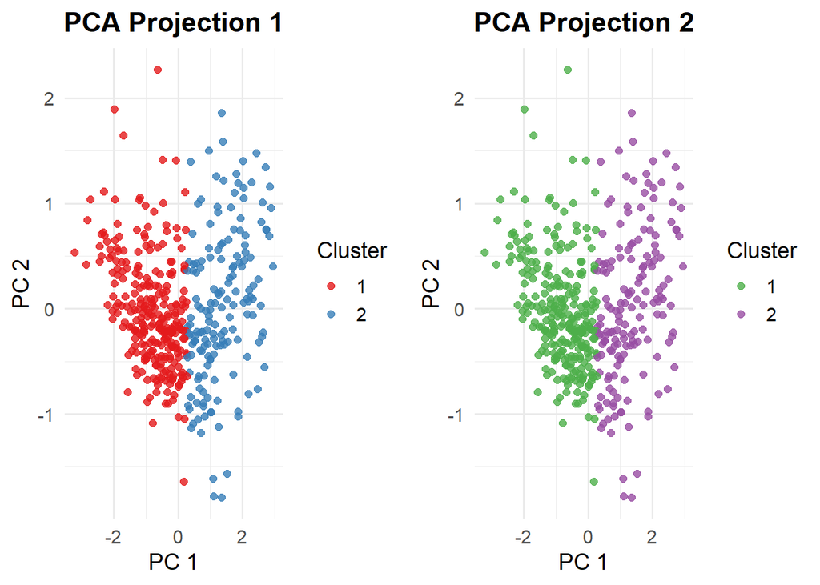

### Hierarchisches Clustering (Single & Complete Linkage)

As we found out earlier, the single linkage makes no sense in our case. I have added it anyway for completeness. However, it is more exciting with the complete linkage, because there again two clusters are recognized in the data, as I can interpret it from the complete linkage denogram, the smaller one comprises about one third of the data and the larger one two thirds.

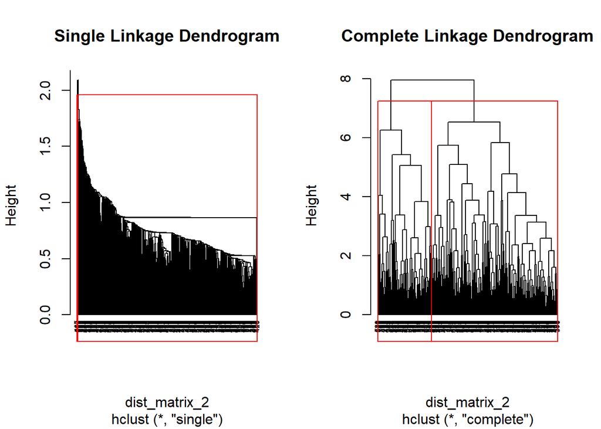

It is also evident from the plots that Single Linkage is not helpful.

However, Complete Linkage does a better job. It is noticeable, though, that some points are classified into the wrong clusters, which will later negatively affect the silhouette width in the analysis.

We conclude that neither Single nor Complete Linkage were helpful for the second part of this analysis.

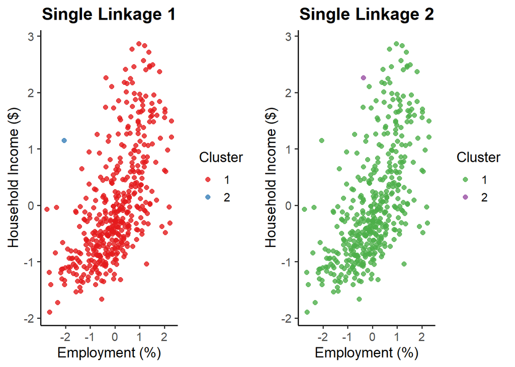

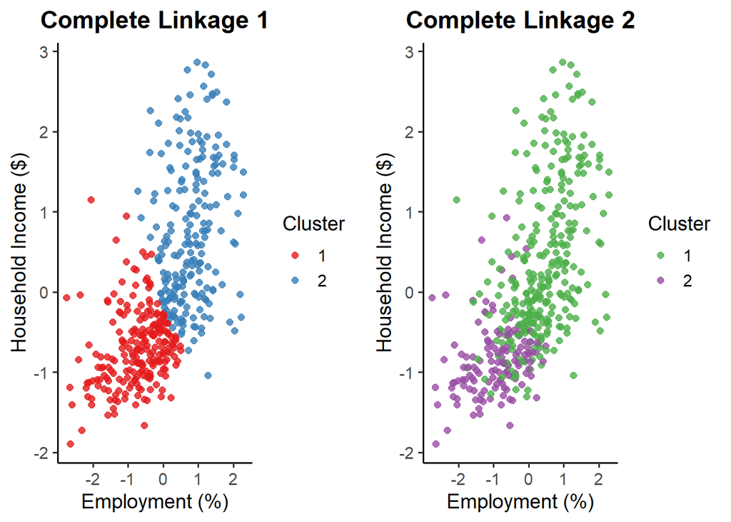

### DB-Scan Clustering

The last clustering method I examined is DBSCAN. I visualized the results both using the original features and within the PCA-reduced dimensions. However, the clusters remained the same in both representations.

When looking at the clustering result, I observe three clusters, but they overlap, and it appears that many points are not correctly classified. This indicates that this clustering algorithm does not work well with the five selected variables.

In comparison to the first dataset, the second dataset performs even worse, in my opinion.

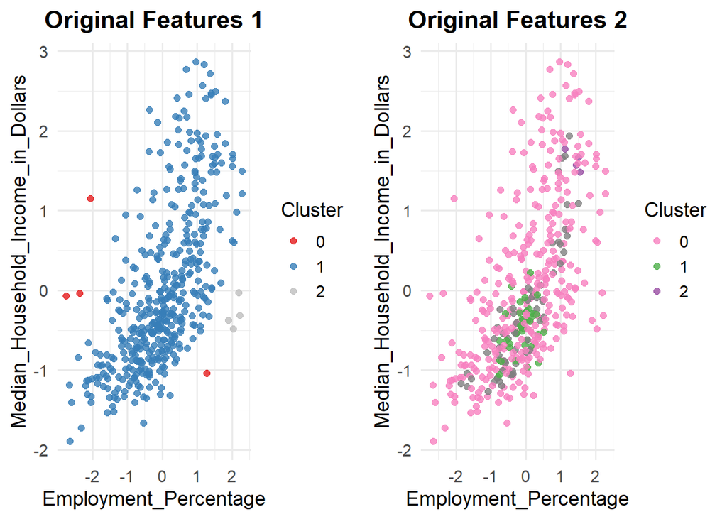

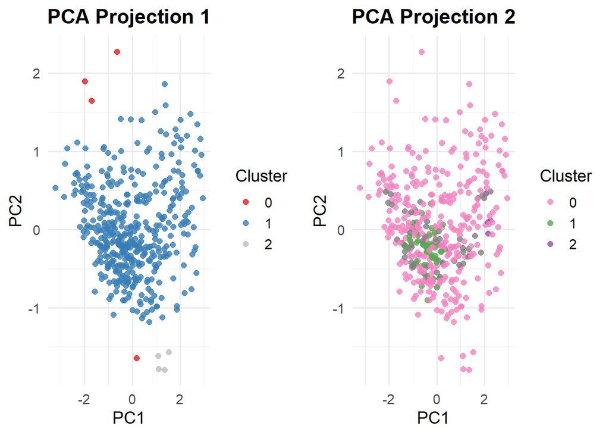

### Silhouette width

Single Linkage clustering achieves a value of only 0.2789, which is not ideal—but understandable, since one of the clusters contains only a single observation.

Most striking is the poor performance of Complete Linkage (0.1822) and DBSCAN, which even yields a negative value of -0.3727. This had already been noted earlier and is clearly visible in the plot.

In conclusion, I believe that due to the strong data standardization and the relatively simple clustering based on few but meaningful variables, it was predictable that k-means with PCA would perform best.

```
## Average Silhouette Width for K-Means Clustering: 0.3069084
```

```
## Average Silhouette Width for Single Linkage Clustering: 0.278916
```

```
## Average Silhouette Width for Complete Linkage Clustering: 0.1821675
```

```
## Average Silhouette Width for DBSCAN Clustering: -0.3726502
```

```
## Average Silhouette Width for PCA and K-Means Clustering: 0.4728028
```

# Conclusion

The analysis conducted in two parts (Part 1 and Part 2) investigated whether the cities in the state of Kentucky can be divided into two or more socio-economic clusters. Using data from the American Community Survey (ACS) and various clustering methods, I was able to identify two wealth classes based on the selected variables.

## Findings

### Clusters in Employment Rate and Median Household Income:

The analysis showed that the cities in Kentucky can be divided into two main clusters. These clusters differ in employment rate and median household income. Cluster 1 represents wealthier cities with higher employment rates and median household incomes, while Cluster 2 includes less wealthy cities with lower values in these variables.

### Influence of Additional Variables

The inclusion of additional variables such as the percentage of people working from home, the percentage of family households, and the percentage of vacant housing had a minor impact on the cluster sizes. However, they helped me better interpret the clusters and understand the two wealth classes. Interestingly, wealthier cities tend to have higher values for the percentage of people working from home and the percentage of family households. This suggests a correlation between economic wealth and certain living and working conditions.

## Conclusions

The analysis confirms my initial objective that socio-economic differences between the cities in Kentucky can be made visible through clustering methods. The results indicate that economic wealth correlates with certain demographic and work-related characteristics. For future analyses, it may be useful to consider additional variables or examine other states to verify the robustness of the results.

## Implications

For example, this analysis can help with more targeted planning regarding which cities should receive more subsidies in the area of family households. By this, I mean that cities with a higher family household percentage could receive more support for childcare facilities or additional funding for playgrounds.

Another interesting point is the “working from home” percentage: is it higher because the city is poorly connected to infrastructure, or because people mainly work in the tertiary sector? I tend to believe it is the latter. Therefore, in these areas, one could consider opening co-working spaces to support remote workers.

Additionally, I believe that the more affluent cities are likely located in larger urban centers or in cities with lower tax rates. One possible approach to balancing this could be to increase taxes in those wealthier cities.

All in all, I think this analysis provides many valuable insights and offers a good overview of the socio-economic situation of the cities in Kentucky.